# 1 Identification & Potential Outcomes

```julia
using CairoMakie
CairoMakie.activate!(type = "png")
using GraphMakie
using Graphs
using GeometryBasics
```

## 1.1 Why Do We Need Tools for Causal Inference?

Association is not causation. We have known how to measure associations for a long time, but most econometric models are associational. The gap between the two arises from confounding.

## 1.2 Confounders

In this graph, $w$ is the treatment, $y$ the outcome, and $c_1$, $c_2$ are confounders. Both confounders affect both $w$ and $y$, so the observed association between $w$ and $y$ may reflect confounding rather than a causal effect.

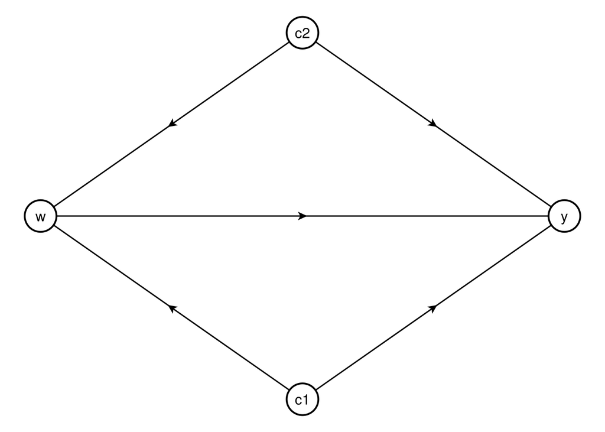

A concrete example: income and age may both drive 401(k) participation and assets. To identify the causal effect of participation on assets, we need to control for income and age.

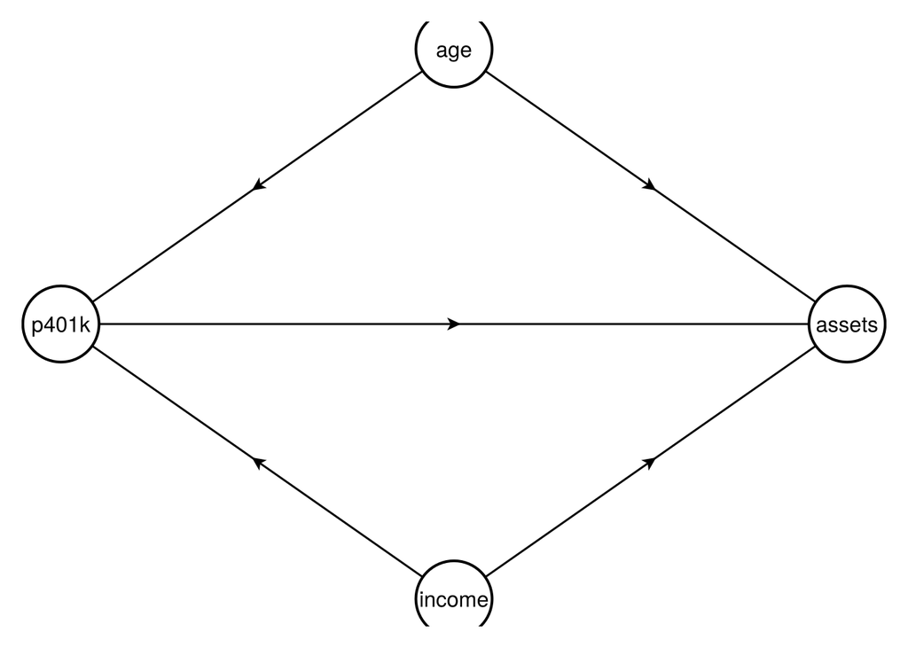

Another example: prenatal care and maternal age may affect both smoking and birth weight. Even if smoking has no causal effect on birth weight, it will appear to because of these shared causes.

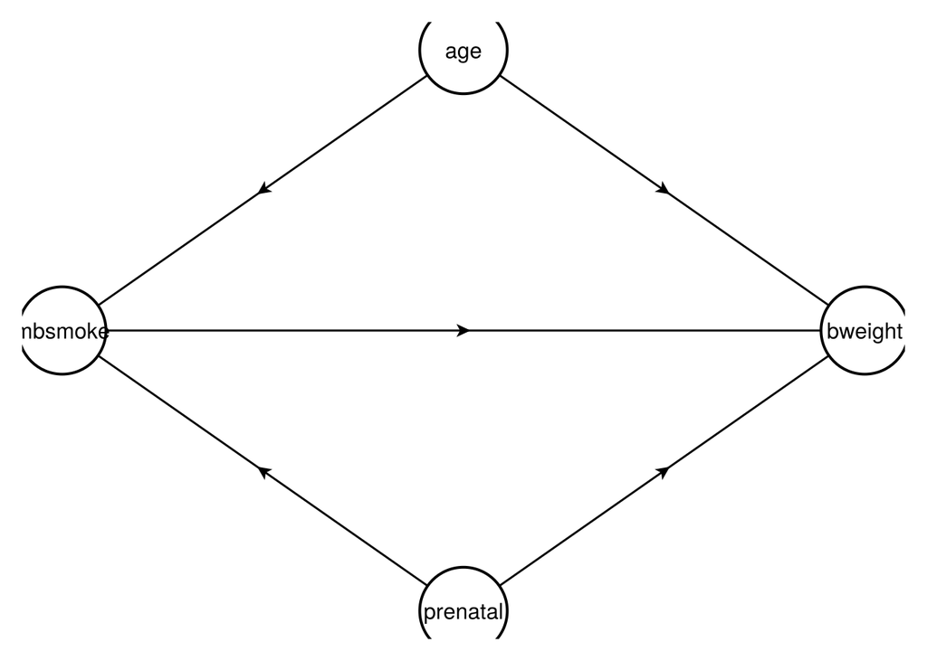

## 1.3 Controlled and Uncontrolled Confounders

If we can control for all confounders, correlation does imply causation. The two questions are: do we observe all confounders, and how do we control for them? In a randomized experiment neither question arises. In an observational study both do. If $c_2$ is unobserved, any estimate of the effect of $w$ on $y$ is biased.

## 1.4 Potential Outcome Setup

We study causal effects through the potential outcomes (counterfactual) framework. Each unit has two potential outcomes, $Y(1)$ and $Y(0)$, one for each treatment state. These are fixed before any assignment; the experiment tries to recover them.

The fundamental problem is that we never observe both: only the realized outcome $Y = WY(1) + (1-W)Y(0)$ is seen. Individual treatment effects $\tau_i = Y_i(1) - Y_i(0)$ are not identifiable; only averages can be estimated.

We write $W$ for treatment assignment and $X$ for covariates.

## 1.5 ATE, ATT and ATU

The standard estimands are:

$$\tau_{ATE} = E[Y(1) - Y(0)] \tag{1.1}$$

$$\tau_{ATT} = E[Y(1) - Y(0) | W=1] \tag{1.2}$$

$$\tau_{ATU} = E[Y(1) - Y(0)| W=0] \tag{1.3}$$

$$\tau_{ATE} = \rho \tau_{ATT} + (1-\rho) \tau_{ATU} \tag{1.4}$$

where $\rho= P(W=1)$.

## 1.6 Identification: From Potential Outcome to Observed

We focus on $\tau_{ATT}$. To identify it, we need:
$$E[Y(1) | W=1] \tag{1.5}$$
which is easy, because we observe it.

And we need
$$E[Y(0) | W=1] \tag{1.6}$$

To identify this, we’ll need unconfoundedness:
$$E[Y(0) | W, X] = E[Y(0)| X] \tag{1.7}$$
and overlap:
$$\pi(x)= P(W=1 | X=x) < 1 \tag{1.8}$$
(for the ATT only $\pi(x)<1$ is needed; the ATE requires $0<\pi(x)<1$).

Unconfoundedness says that within each subgroup $X=x$, treated and control units have the same mean of $Y(0)$: $E[Y(0)|W=1,X=x]=E[Y(0)|W=0,X=x]=E[Y|W=0,X=x]$. Averaging over the covariate distribution of the treated,

$$E[Y(0)| W=1] = E\big[ E[Y | W=0, X] \mid W=1 \big], \tag{1.9}$$

which involves only observed data. Therefore ATT is identified:

$$\begin{aligned}
\tau_{ATT} &= E[Y(1) - Y(0) | W=1] \\
&= E[Y|W=1] - E\big[ E[Y | W=0, X] \mid W=1 \big]
\end{aligned}
\tag{1.10}$$

Note the conditional-on-$X$ assumption does NOT imply the marginal equality $E[Y(0)|W=1]=E[Y(0)|W=0]$: treated and control units have different covariate distributions, so the adjustment over $X$ is essential. In a randomised experiment, unconfoundedness holds without conditioning on $X$ (i.e. $E[Y(0)|W]=E[Y(0)]$); then $E[Y(0)|W=1]=E[Y(0)|W=0]=E[Y|W=0]$, the formula collapses to $E[Y|W=1]-E[Y|W=0]$, and a difference-in-means estimator is consistent.

$$\hat{\tau}_{ATT} = \bar Y_1 - \bar Y_0 \tag{1.11}$$

But in observational studies, most cases we cannot assume unconfoundedness. What can we do to justify unconfoundedness better?

## 1.7 Unconfoundedness and Overlap

Weaker Assumptions: Unconfoundedness in mean form, stated for both potential outcomes since we are after the ATE here (as opposed to the ATT case above, which only required it for $Y(0)$). This is conditional mean independence:
$$E[Y(d) | W, X] = E[Y(d)| X] \quad \text{for } d \in \{0,1\} \tag{1.12}$$
Overlap:
$$0 < \pi(x)= P(W=1 | X=x) < 1 \tag{1.13}$$
SUTVA (stable unit treatment value assumption): 1. No interference between units. No spillovers. 2. Consistency. No hidden versions of treatment or control. Treatment is clearly defined.

Within each subgroup of $X=x$, the mean of each potential outcome does not depend on $W$. That is enough for mean estimands, the ATE, ATT and CATE. It is weaker than ignorability in the sense of Rosenbaum and Rubin (1983), $(Y(0), Y(1)) \perp W \mid X$, full conditional independence, which distributional estimands such as the QTE require. With the overlap assumption, we ensure there is a comparable control unit for each treated unit.

However, these two criteria are often contradictory: we may need more covariates to satisfy conditional independence; meanwhile, if the dimension of covariates goes high, then it’s likely in some partition we don’t have control units.

We need four assumptions for identification:

- Unconfoundedness (conditional independence, or ignorability)
- Overlap (positivity, common support)
- No interference
- Consistency

The last two together are SUTVA, the stable unit treatment value assumption (Rubin 1980).

## 1.8 Observational Data Flowchart

In observational studies, I summarise the decision what method to use for identification of causal effect:

```
%%{init: {'flowchart': {'diagramPadding': 30}}}%%
flowchart LR
  A[Observational data Y,W,X] --> B{Unconfoundedness?}
  B --> | Yes | C{Parametric?}
  C --> | Yes | D(RA)
  C --> | Yes | E(IPW)
  C --> | Yes | F(AIPW)
  C --> | Yes | G(IPWRA)
  C --> | No | H(IF based estimators)
  C --> | No | I(TMLE)
  C --> | No | J(DoubleML)
  B --> | No | K{Panel data?}
  K --> | Yes | L{Parallel Trend?}
  L --> | Yes | M(DID)
  L --> | No | N(Synthetic Control)
  L --> | No | O(Synthetic DID)
  K --> | No | P{Instrument?}
  P --> | Yes | Q(IV or RDD)
  P --> | No | R(You are stuck!)
```

## 1.9 Summary

A causal effect compares two potential outcomes, $Y(1)$ and $Y(0)$, and we only ever see one of them. So we target averages, the ATE, ATT and ATU, and identification means writing them in terms of observed data. Under unconfoundedness given the covariates $X$ and overlap, the ATT equals the treated mean minus the control mean adjusted to the covariate distribution of the treated. Two more conditions, no interference and consistency, make the observed outcome equal to the right potential outcome.

When unconfoundedness is not credible, other designs replace it with their own assumptions: parallel trends for DiD, a factor structure for synthetic control, continuity at a cutoff for regression discontinuity, and a relevant and excludable instrument for IV. The flowchart maps these choices, and the rest of the book develops each one.

Rosenbaum, Paul R., and Donald B. Rubin. 1983. “The Central Role of the Propensity Score in Observational Studies for Causal Effects.” *Biometrika* 70 (1): 41–55.

Rubin, Donald B. 1980. “Randomization Analysis of Experimental Data: The Fisher Randomization Test Comment.” *Journal of the American Statistical Association* 75 (371): 591–93.